# Kira Plastinina’s customer-cluster analysis

### Hierachical clustering

```r
# First we use the dist() function to compute the Euclidean distance between observations,
# d will be the first argument in the hclust() function dissimilarity matrix
# ---
#
d <- dist(kp.encod, method = "euclidean")
# We then hierarchical clustering using the Ward's method
# ---
#
res.hc <- hclust(d, method = "ward.D2" )
res.hc
```

```
##
## Call:
## hclust(d = d, method = "ward.D2")
##
## Cluster method   : ward.D2
## Distance         : euclidean
## Number of objects: 12199
```

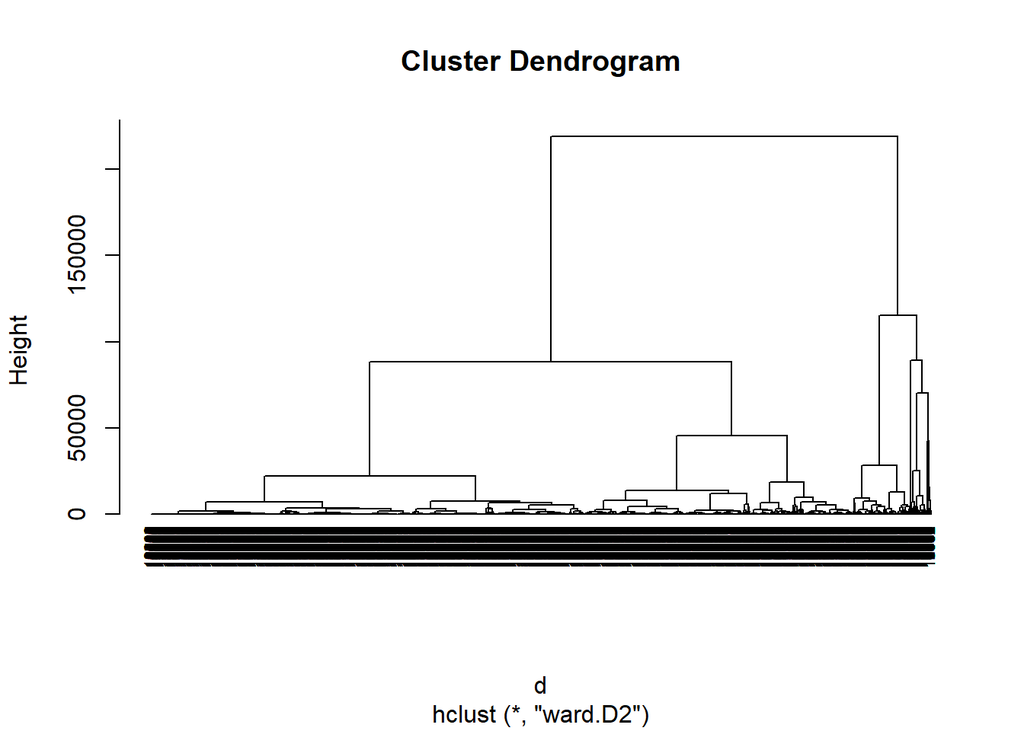

```r
# plotting the obtained dendrogram
# ---
#
plot(res.hc, cex = 0.6, hang = -1)
```

## RECOMMENDATIONS

Owing to the fact that the aim of any business is to generate more revenue than the cost it incurs, Kira Plastinina’s Sales and Marketing should: 1. Target to increase their reach in regions 1 and 3 as they seem to be the regions with the most visits 2. Market themselves more in the months of May, November, December and March as these are the months with the most hits. 3, Ensure that in the month of November they have majority of their items up on the website as the most revenue is generated around that time. 4. Ensure their site is running targeted ads over the weekday as this is the period when most of their clients are on 5. Strive to ensure they retain every customer who cicks their site as this forms the bulk of their revenue as well as the site visits